# Bellabeat Case Study: Fitbit User Behaviour Analysis Using Python

## Project Introduction

Bellabeat is a high-tech wellness company that develops smart products designed to help women monitor and improve their health. As the company seeks to expand its market presence, understanding how consumers interact with wearable fitness devices can provide valuable insights for product development and marketing strategy.

This project analyzes Fitbit fitness tracker data to explore user behaviour related to physical activity, sleep patterns, calorie expenditure, heart rate monitoring, and weight tracking. Through data preparation, feature engineering, exploratory analysis, and business-focused interpretation, the study aims to identify behavioural trends that can support data-driven decision-making.

The analysis follows a structured analytics workflow, including data cleaning, validation, relational integration, exploratory data analysis, and strategic recommendation development. The findings are intended to demonstrate how wearable device data can be transformed into actionable business insights that support customer engagement and wellness-focused product innovation.

## Business Task

Analyze smart device usage data to identify behavioural trends and generate actionable recommendations that can inform Bellabeat's marketing strategy and product development initiatives.

## Project Workflow

1. Data Preparation
2. Feature Engineering
3. Data Modeling
4. Exploratory Data Analysis
5. Business Insights & Recommendations

# STEP 1.0 - DATA ACQUISITION

```python
# ===============================================
# STEP 1.1 - IMPORT LIBRARIES
# ===============================================

import pandas as pd
import numpy as np

import matplotlib.pyplot as plt
import seaborn as sns

# Display settings
pd.set_option('display.max_columns', None)
pd.set_option('display.float_format', '{:.2f}'.format)

# Visualization settings
sns.set_style("whitegrid")
```

```python
# ===============================================
# STEP 1.2 -LOAD ALL DATASETS
# ===============================================

# Daily activity dataset
daily_activity = pd.read_csv("../data/raw/dailyActivity_merged.csv")

# Sleep dataset
sleep = pd.read_csv("../data/raw/sleepDay_merged.csv")

# Hourly steps dataset
hourly_steps = pd.read_csv("../data/raw/hourlySteps_merged.csv")

# Hourly calories dataset
hourly_calories = pd.read_csv("../data/raw/hourlyCalories_merged.csv")

# Heart rate dataset
heart_rate = pd.read_csv("../data/raw/heartrate_seconds_merged.csv")

# Weight log dataset
weight_log = pd.read_csv("../data/raw/weightLogInfo_merged.csv")
```

# STEP 2.0 - DATA PREPARATION

```python
# ===============================================
# STEP 2.1 - STRUCTURAL PROFILING BEFORE CLEANING
# ===============================================

# STEP 2.0 - DATASET REGISTRY

datasets = {
    "daily_activity": daily_activity,
    "sleep": sleep,
    "hourly_steps": hourly_steps,
    "hourly_calories": hourly_calories,
    "heart_rate": heart_rate,
    "weight_log": weight_log
}

# STEP 2.1 - STRUCTURAL PROFILING

for name, df in datasets.items():

    print("=" * 70)
    print(f"{name.upper()} DATASET")
    print("=" * 70)

    # Shape
    print(f"\nShape: {df.shape}")

    # Columns
    print("\nColumn Names:")
    print(df.columns.tolist())

    # Data Types
    print("\nData Types:")
    print(df.dtypes)

    # Missing Values
    print("\nMissing Values:")
    print(df.isnull().sum())

    # Duplicate Rows
    print("\nDuplicate Rows:")
    print(df.duplicated().sum())

    # Memory Usage
    memory = df.memory_usage(deep=True).sum() / 1024**2
    print(f"\nMemory Usage: {memory:.2f} MB")

    # First Records
    print("\nFirst 5 Records:")
    display(df.head())

    print("\n\n")
```

```
======================================================================
DAILY_ACTIVITY DATASET
======================================================================

Shape: (940, 15)

Column Names:
['Id', 'ActivityDate', 'TotalSteps', 'TotalDistance', 'TrackerDistance', 'LoggedActivitiesDistance', 'VeryActiveDistance', 'ModeratelyActiveDistance', 'LightActiveDistance', 'SedentaryActiveDistance', 'VeryActiveMinutes', 'FairlyActiveMinutes', 'LightlyActiveMinutes', 'SedentaryMinutes', 'Calories']

Data Types:
Id                            int64
ActivityDate                    str
TotalSteps                    int64
TotalDistance               float64
TrackerDistance             float64
LoggedActivitiesDistance    float64
VeryActiveDistance          float64
ModeratelyActiveDistance    float64
LightActiveDistance         float64
SedentaryActiveDistance     float64
VeryActiveMinutes             int64
FairlyActiveMinutes           int64
LightlyActiveMinutes          int64
SedentaryMinutes              int64
Calories                      int64
dtype: object

Missing Values:
Id                          0
ActivityDate                0
TotalSteps                  0
TotalDistance               0
TrackerDistance             0
LoggedActivitiesDistance    0
VeryActiveDistance          0
ModeratelyActiveDistance    0
LightActiveDistance         0
SedentaryActiveDistance     0
VeryActiveMinutes           0
FairlyActiveMinutes         0
LightlyActiveMinutes        0
SedentaryMinutes            0
Calories                    0
dtype: int64

Duplicate Rows:
0

Memory Usage: 0.15 MB

First 5 Records:
```

|  | Id | ActivityDate | TotalSteps | TotalDistance | TrackerDistance | LoggedActivitiesDistance | VeryActiveDistance | ModeratelyActiveDistance | LightActiveDistance | SedentaryActiveDistance | VeryActiveMinutes | FairlyActiveMinutes | LightlyActiveMinutes | SedentaryMinutes | Calories |
| --- | --- | --- | --- | --- | --- | --- | --- | --- | --- | --- | --- | --- | --- | --- | --- |
| 0 | 1503960366 | 4/12/2016 | 13162 | 8.50 | 8.50 | 0.00 | 1.88 | 0.55 | 6.06 | 0.00 | 25 | 13 | 328 | 728 | 1985 |
| 1 | 1503960366 | 4/13/2016 | 10735 | 6.97 | 6.97 | 0.00 | 1.57 | 0.69 | 4.71 | 0.00 | 21 | 19 | 217 | 776 | 1797 |
| 2 | 1503960366 | 4/14/2016 | 10460 | 6.74 | 6.74 | 0.00 | 2.44 | 0.40 | 3.91 | 0.00 | 30 | 11 | 181 | 1218 | 1776 |
| 3 | 1503960366 | 4/15/2016 | 9762 | 6.28 | 6.28 | 0.00 | 2.14 | 1.26 | 2.83 | 0.00 | 29 | 34 | 209 | 726 | 1745 |
| 4 | 1503960366 | 4/16/2016 | 12669 | 8.16 | 8.16 | 0.00 | 2.71 | 0.41 | 5.04 | 0.00 | 36 | 10 | 221 | 773 | 1863 |

```
======================================================================
SLEEP DATASET
======================================================================

Shape: (413, 5)

Column Names:
['Id', 'SleepDay', 'TotalSleepRecords', 'TotalMinutesAsleep', 'TotalTimeInBed']

Data Types:
Id                    int64
SleepDay                str
TotalSleepRecords     int64
TotalMinutesAsleep    int64
TotalTimeInBed        int64
dtype: object

Missing Values:
Id                    0
SleepDay              0
TotalSleepRecords     0
TotalMinutesAsleep    0
TotalTimeInBed        0
dtype: int64

Duplicate Rows:
3

Memory Usage: 0.04 MB

First 5 Records:
```

|  | Id | SleepDay | TotalSleepRecords | TotalMinutesAsleep | TotalTimeInBed |
| --- | --- | --- | --- | --- | --- |
| 0 | 1503960366 | 4/12/2016 12:00:00 AM | 1 | 327 | 346 |
| 1 | 1503960366 | 4/13/2016 12:00:00 AM | 2 | 384 | 407 |
| 2 | 1503960366 | 4/15/2016 12:00:00 AM | 1 | 412 | 442 |
| 3 | 1503960366 | 4/16/2016 12:00:00 AM | 2 | 340 | 367 |
| 4 | 1503960366 | 4/17/2016 12:00:00 AM | 1 | 700 | 712 |

```
======================================================================
HOURLY_STEPS DATASET
======================================================================

Shape: (22099, 3)

Column Names:
['Id', 'ActivityHour', 'StepTotal']

Data Types:
Id              int64
ActivityHour      str
StepTotal       int64
dtype: object

Missing Values:
Id              0
ActivityHour    0
StepTotal       0
dtype: int64

Duplicate Rows:
0

Memory Usage: 1.79 MB

First 5 Records:
```

|  | Id | ActivityHour | StepTotal |
| --- | --- | --- | --- |
| 0 | 1503960366 | 4/12/2016 12:00:00 AM | 373 |
| 1 | 1503960366 | 4/12/2016 1:00:00 AM | 160 |
| 2 | 1503960366 | 4/12/2016 2:00:00 AM | 151 |
| 3 | 1503960366 | 4/12/2016 3:00:00 AM | 0 |
| 4 | 1503960366 | 4/12/2016 4:00:00 AM | 0 |

```
======================================================================
HOURLY_CALORIES DATASET
======================================================================

Shape: (22099, 3)

Column Names:
['Id', 'ActivityHour', 'Calories']

Data Types:
Id              int64
ActivityHour      str
Calories        int64
dtype: object

Missing Values:
Id              0
ActivityHour    0
Calories        0
dtype: int64

Duplicate Rows:
0

Memory Usage: 1.79 MB

First 5 Records:
```

|  | Id | ActivityHour | Calories |
| --- | --- | --- | --- |
| 0 | 1503960366 | 4/12/2016 12:00:00 AM | 81 |
| 1 | 1503960366 | 4/12/2016 1:00:00 AM | 61 |
| 2 | 1503960366 | 4/12/2016 2:00:00 AM | 59 |
| 3 | 1503960366 | 4/12/2016 3:00:00 AM | 47 |
| 4 | 1503960366 | 4/12/2016 4:00:00 AM | 48 |

```
======================================================================
HEART_RATE DATASET
======================================================================

Shape: (2483658, 3)

Column Names:
['Id', 'Time', 'Value']

Data Types:
Id       int64
Time       str
Value    int64
dtype: object

Missing Values:
Id       0
Time     0
Value    0
dtype: int64

Duplicate Rows:
0

Memory Usage: 201.22 MB

First 5 Records:
```

|  | Id | Time | Value |
| --- | --- | --- | --- |
| 0 | 2022484408 | 4/12/2016 7:21:00 AM | 97 |
| 1 | 2022484408 | 4/12/2016 7:21:05 AM | 102 |
| 2 | 2022484408 | 4/12/2016 7:21:10 AM | 105 |
| 3 | 2022484408 | 4/12/2016 7:21:20 AM | 103 |
| 4 | 2022484408 | 4/12/2016 7:21:25 AM | 101 |

```
======================================================================
WEIGHT_LOG DATASET
======================================================================

Shape: (67, 8)

Column Names:
['Id', 'Date', 'WeightKg', 'WeightPounds', 'Fat', 'BMI', 'IsManualReport', 'LogId']

Data Types:
Id                  int64
Date                  str
WeightKg          float64
WeightPounds      float64
Fat               float64
BMI               float64
IsManualReport       bool
LogId               int64
dtype: object

Missing Values:
Id                 0
Date               0
WeightKg           0
WeightPounds       0
Fat               65
BMI                0
IsManualReport     0
LogId              0
dtype: int64

Duplicate Rows:
0

Memory Usage: 0.01 MB

First 5 Records:
```

|  | Id | Date | WeightKg | WeightPounds | Fat | BMI | IsManualReport | LogId |
| --- | --- | --- | --- | --- | --- | --- | --- | --- |
| 0 | 1503960366 | 5/2/2016 11:59:59 PM | 52.60 | 115.96 | 22.00 | 22.65 | True | 1462233599000 |
| 1 | 1503960366 | 5/3/2016 11:59:59 PM | 52.60 | 115.96 | NaN | 22.65 | True | 1462319999000 |
| 2 | 1927972279 | 4/13/2016 1:08:52 AM | 133.50 | 294.32 | NaN | 47.54 | False | 1460509732000 |
| 3 | 2873212765 | 4/21/2016 11:59:59 PM | 56.70 | 125.00 | NaN | 21.45 | True | 1461283199000 |
| 4 | 2873212765 | 5/12/2016 11:59:59 PM | 57.30 | 126.32 | NaN | 21.69 | True | 1463097599000 |

## STRUCTURAL PROFILING SUMMARY

A comprehensive structural profiling assessment was conducted across all six Fitbit datasets to evaluate data integrity, schema consistency, completeness, and analytical readiness prior to preprocessing and exploratory analysis. The profiling stage focused on understanding dataset granularity, variable structure, datatype validity, missing value distribution, duplication risk, and computational characteristics. The analytical environment consists of six relational datasets representing different dimensions of user wellness behaviour:

1. Daily_activity
2. Sleep
3. Hourly_steps
4. Hourly_calories
5. Heart_rate
6. Weight_log

These datasets collectively capture user activity, sleep behaviour, calorie expenditure, heart rate monitoring, and weight tracking across multiple temporal resolutions, including daily, hourly, and second-level granularity. Structural inspection revealed that the datasets are generally well-organized and analytically coherent. Most variables were successfully interpreted using appropriate numerical datatypes (`int64` and `float64`), particularly for activity metrics, physiological measurements, and distance-related variables. However, temporal attributes such as `ActivityDate`, `SleepDay`, `ActivityHour`, and `Time` were initially stored as string (`object`) datatypes rather than native datetime formats. This creates limitations for temporal aggregation, time-series analysis, and feature engineering, necessitating datetime normalization during preprocessing. Data quality assessment showed relatively strong structural integrity across the datasets. Most tables exhibited low or negligible missing-value distributions, particularly within the core behavioural datasets (`daily_activity`, `hourly_steps`, and `hourly_calories`). Duplicate auditing similarly indicated minimal row-level duplication, suggesting that the exported Fitbit records maintain acceptable transactional consistency.

The datasets also exhibit varying levels of granularity and analytical complexity. Daily-level datasets (`Daily_activity` and `sleep`) provide aggregated behavioural summaries suitable for high-level wellness analysis and user segmentation. Hourly datasets (`hourly_steps` and `hourly_calories`) introduce finer temporal resolution for activity-pattern analysis and intraday behavioural profiling. In contrast, the `heart_rate` dataset operates at second-level granularity, representing a high-frequency physiological time-series structure requiring aggregation and optimization prior to integration with lower-granularity tables. The `weight_log` dataset functions as an event-based tracking table with comparatively sparse observations. Memory profiling indicated that most datasets are computationally lightweight and suitable for in-memory processing. However, the second-level heart-rate dataset demonstrates substantially higher memory consumption relative to the remaining tables, highlighting the need for careful aggregation and datatype optimization during preprocessing. Overall, the structural profiling stage confirms that the Fitbit data ecosystem possesses strong analytical potential with relatively high structural consistency and low integrity risk. Nevertheless, preprocessing operations remain necessary to standardize temporal datatypes, normalize schema conventions, validate numerical integrity, and align dataset granularity prior to relational merging and downstream exploratory analysis.

```python
# =========================================
# STEP 2.2 - STANDARDIZATION & VALIDATION
# =========================================

column_audit = {}

for name, df in datasets.items():

    # Store original column names
    original_columns = df.columns.tolist()

    # Standardize column names
    df.columns = (
        df.columns
        .str.strip()
        .str.lower()
    )

    # Store transformed column names
    standardized_columns = df.columns.tolist()

    # Save audit trail
    column_audit[name] = {
        "before": original_columns,
        "after": standardized_columns
    }

# ==================================
# COLUMN STANDARDIZATION VALIDATION
# ==================================

for dataset, audit in column_audit.items():

    print("=" * 70)
    print(f"{dataset.upper()} COLUMN STANDARDIZATION")
    print("=" * 70)

    print("\nBEFORE:")
    print(audit["before"])

    print("\nAFTER:")
    print(audit["after"])

    print("\n")
```

```
======================================================================
DAILY_ACTIVITY COLUMN STANDARDIZATION
======================================================================

BEFORE:
['Id', 'ActivityDate', 'TotalSteps', 'TotalDistance', 'TrackerDistance', 'LoggedActivitiesDistance', 'VeryActiveDistance', 'ModeratelyActiveDistance', 'LightActiveDistance', 'SedentaryActiveDistance', 'VeryActiveMinutes', 'FairlyActiveMinutes', 'LightlyActiveMinutes', 'SedentaryMinutes', 'Calories']

AFTER:
['id', 'activitydate', 'totalsteps', 'totaldistance', 'trackerdistance', 'loggedactivitiesdistance', 'veryactivedistance', 'moderatelyactivedistance', 'lightactivedistance', 'sedentaryactivedistance', 'veryactiveminutes', 'fairlyactiveminutes', 'lightlyactiveminutes', 'sedentaryminutes', 'calories']


======================================================================
SLEEP COLUMN STANDARDIZATION
======================================================================

BEFORE:
['Id', 'SleepDay', 'TotalSleepRecords', 'TotalMinutesAsleep', 'TotalTimeInBed']

AFTER:
['id', 'sleepday', 'totalsleeprecords', 'totalminutesasleep', 'totaltimeinbed']


======================================================================
HOURLY_STEPS COLUMN STANDARDIZATION
======================================================================

BEFORE:
['Id', 'ActivityHour', 'StepTotal']

AFTER:
['id', 'activityhour', 'steptotal']


======================================================================
HOURLY_CALORIES COLUMN STANDARDIZATION
======================================================================

BEFORE:
['Id', 'ActivityHour', 'Calories']

```

[output cut: 9 more lines]

```
['Id', 'Time', 'Value']

AFTER:
['id', 'time', 'value']


======================================================================
WEIGHT_LOG COLUMN STANDARDIZATION
======================================================================

BEFORE:
['Id', 'Date', 'WeightKg', 'WeightPounds', 'Fat', 'BMI', 'IsManualReport', 'LogId']

AFTER:
['id', 'date', 'weightkg', 'weightpounds', 'fat', 'bmi', 'ismanualreport', 'logid']
```

```python
# ===============================================
# STEP 2.3 - DATETIME NORMALIZATION & VALIDATION
# ===============================================

# Datetime conversion
daily_activity['activitydate'] = pd.to_datetime(
    daily_activity['activitydate'],
    format='%m/%d/%Y',
    errors='coerce'
)

sleep['sleepday'] = pd.to_datetime(
    sleep['sleepday'],
    format='%m/%d/%Y %I:%M:%S %p',
    errors='coerce'
)

hourly_steps['activityhour'] = pd.to_datetime(
    hourly_steps['activityhour'],
    format='%m/%d/%Y %I:%M:%S %p',
    errors='coerce'
)

hourly_calories['activityhour'] = pd.to_datetime(
    hourly_calories['activityhour'],
    format='%m/%d/%Y %I:%M:%S %p',
    errors='coerce'
)

heart_rate['time'] = pd.to_datetime(
    heart_rate['time'],
    format='%m/%d/%Y %I:%M:%S %p',
    errors='coerce'
)

weight_log['date'] = pd.to_datetime(
    weight_log['date'],
    format='%m/%d/%Y %I:%M:%S %p',
    errors='coerce'
)

# ===============================================
# DATETIME VALIDATION
# ===============================================

datetime_validation = {
    "daily_activity": daily_activity['activitydate'].dtype,
    "sleep": sleep['sleepday'].dtype,
    "hourly_steps": hourly_steps['activityhour'].dtype,
    "hourly_calories": hourly_calories['activityhour'].dtype,
    "heart_rate": heart_rate['time'].dtype,
    "weight_log": weight_log['date'].dtype
}

print("=" * 70)
print("DATETIME CONVERSION VALIDATION")
print("=" * 70)

for dataset, dtype in datetime_validation.items():
    print(f"{dataset:<20} → {dtype}")
```

```
======================================================================
DATETIME CONVERSION VALIDATION
======================================================================
daily_activity       → datetime64[us]
sleep                → datetime64[us]
hourly_steps         → datetime64[us]
hourly_calories      → datetime64[us]
heart_rate           → datetime64[us]
weight_log           → datetime64[us]
```

```python
# ===============================================
# STEP 2.4 - DUPLICATE MANAGEMENT
# ===============================================

sleep_before = sleep.shape[0]

sleep = sleep.drop_duplicates()

sleep_after = sleep.shape[0]

print("=" * 70)
print("SLEEP DUPLICATE REMOVAL")
print("=" * 70)
print(f"Rows Before : {sleep_before}")
print(f"Rows After  : {sleep_after}")
print(f"Removed     : {sleep_before - sleep_after}")
```

```
======================================================================
SLEEP DUPLICATE REMOVAL
======================================================================
Rows Before : 413
Rows After  : 410
Removed     : 3
```

```python
# ===============================================
# STEP 2.5 - MISSING VALUE TREATMENT
# ===============================================

weight_log = weight_log.drop(columns=['fat'])

print("=" * 70)
print("WEIGHT LOG COLUMN REMOVAL")
print("=" * 70)
print("Removed Column: fat")
print("\nRemaining Columns:")
print(weight_log.columns.tolist())
```

```
======================================================================
WEIGHT LOG COLUMN REMOVAL
======================================================================
Removed Column: fat

Remaining Columns:
['id', 'date', 'weightkg', 'weightpounds', 'bmi', 'ismanualreport', 'logid']
```

```python
# ===============================================
# STEP 2.6 - DATA QUALITY VALIDATION
# ===============================================

validation_results = {}

# -----------------------------------------------
# DAILY ACTIVITY VALIDATION
# -----------------------------------------------

validation_results['daily_activity'] = {

    "negative_steps": (
        daily_activity['totalsteps'] < 0
    ).sum(),

    "negative_calories": (
        daily_activity['calories'] < 0
    ).sum(),

    "negative_distances": (
        daily_activity['totaldistance'] < 0
    ).sum(),

    "negative_active_minutes": (
        daily_activity['veryactiveminutes'] < 0
    ).sum(),

    "invalid_sedentary_minutes": (
        daily_activity['sedentaryminutes'] > 1440
    ).sum()
}

# -----------------------------------------------
# SLEEP DATA VALIDATION
# -----------------------------------------------

validation_results['sleep'] = {

    "negative_sleep_minutes": (
        sleep['totalminutesasleep'] < 0
    ).sum(),

    "invalid_sleep_duration": (
        sleep['totalminutesasleep'] > 1440
    ).sum(),

    "negative_time_in_bed": (
        sleep['totaltimeinbed'] < 0
    ).sum()
}

# -----------------------------------------------
# HOURLY STEPS VALIDATION
# -----------------------------------------------

validation_results['hourly_steps'] = {

    "negative_hourly_steps": (
        hourly_steps['steptotal'] < 0
    ).sum()
}

# -----------------------------------------------
# HOURLY CALORIES VALIDATION
# -----------------------------------------------

validation_results['hourly_calories'] = {

    "negative_hourly_calories": (
        hourly_calories['calories'] < 0
    ).sum()
}

# -----------------------------------------------
# HEART RATE VALIDATION
# -----------------------------------------------

validation_results['heart_rate'] = {

    "negative_heart_rate": (
        heart_rate['value'] < 0
    ).sum(),

    "extreme_heart_rate": (
        heart_rate['value'] > 220
    ).sum()
}

# -----------------------------------------------
# WEIGHT LOG VALIDATION
# -----------------------------------------------

validation_results['weight_log'] = {

    "negative_weight": (
        weight_log['weightkg'] < 0
    ).sum(),

    "negative_bmi": (
        weight_log['bmi'] < 0
    ).sum()
}

# ===============================================
# VALIDATION OUTPUT
# ===============================================

print("=" * 70)
print("DATA QUALITY VALIDATION RESULTS")
print("=" * 70)

for dataset, checks in validation_results.items():

    print(f"\n{dataset.upper()}")

    for check, result in checks.items():

        print(f"{check:<35} : {result}")
```

```
======================================================================
DATA QUALITY VALIDATION RESULTS
======================================================================

DAILY_ACTIVITY
negative_steps                      : 0
negative_calories                   : 0
negative_distances                  : 0
negative_active_minutes             : 0
invalid_sedentary_minutes           : 0

SLEEP
negative_sleep_minutes              : 0
invalid_sleep_duration              : 0
negative_time_in_bed                : 0

HOURLY_STEPS
negative_hourly_steps               : 0

HOURLY_CALORIES
negative_hourly_calories            : 0

HEART_RATE
negative_heart_rate                 : 0
extreme_heart_rate                  : 0

WEIGHT_LOG
negative_weight                     : 0
negative_bmi                        : 0
```

```python
# ===============================================
# STEP 2.7 - REFRESH DATASET REGISTRY
# ===============================================

datasets = {
    "daily_activity": daily_activity,
    "sleep": sleep,
    "hourly_steps": hourly_steps,
    "hourly_calories": hourly_calories,
    "heart_rate": heart_rate,
    "weight_log": weight_log
}
```

```python
# ===============================================
# STEP 2.8 - DATA CLEANING READINESS ASSESSMENT
# ===============================================

readiness_summary = pd.DataFrame({

    "Dataset": [
        "daily_activity",
        "sleep",
        "hourly_steps",
        "hourly_calories",
        "heart_rate",
        "weight_log"
    ],

    "Rows": [
        len(daily_activity),
        len(sleep),
        len(hourly_steps),
        len(hourly_calories),
        len(heart_rate),
        len(weight_log)
    ],

    "Columns": [
        daily_activity.shape[1],
        sleep.shape[1],
        hourly_steps.shape[1],
        hourly_calories.shape[1],
        heart_rate.shape[1],
        weight_log.shape[1]
    ],

    "Missing Values": [
        daily_activity.isnull().sum().sum(),
        sleep.isnull().sum().sum(),
        hourly_steps.isnull().sum().sum(),
        hourly_calories.isnull().sum().sum(),
        heart_rate.isnull().sum().sum(),
        weight_log.isnull().sum().sum()
    ],

    "Duplicate Rows": [
        daily_activity.duplicated().sum(),
        sleep.duplicated().sum(),
        hourly_steps.duplicated().sum(),
        hourly_calories.duplicated().sum(),
        heart_rate.duplicated().sum(),
        weight_log.duplicated().sum()
    ]
})

display(readiness_summary)
```

|  | Dataset | Rows | Columns | Missing Values | Duplicate Rows |
| --- | --- | --- | --- | --- | --- |
| 0 | daily_activity | 940 | 15 | 0 | 0 |
| 1 | sleep | 410 | 5 | 0 | 0 |
| 2 | hourly_steps | 22099 | 3 | 0 | 0 |
| 3 | hourly_calories | 22099 | 3 | 0 | 0 |
| 4 | heart_rate | 2483658 | 3 | 0 | 0 |
| 5 | weight_log | 67 | 7 | 0 | 0 |

## DATA CLEANING READINESS SUMMARY

The data quality validation process indicates that the Fitbit datasets exhibit strong structural integrity and are suitable for downstream analytical processing.

Datetime variables were successfully converted to native datetime formats, enabling temporal analysis, feature engineering, and time-based aggregation. Column names were standardized to improve consistency, readability, and maintainability across the analytical workflow.

Quality validation checks identified no material issues relating to negative activity measurements, implausible physiological observations, or invalid duration-based metrics. Duplicate assessment revealed three duplicate records within the sleep dataset, which were removed during preprocessing to preserve data integrity.

Missing value analysis identified substantial missingness within the `fat` variable of the weight log dataset (65 missing values out of 67 observations, approximately 97% missingness). Given the limited analytical value and high degree of incompleteness, the variable was excluded from further analysis, while all remaining weight-related attributes were retained.

Following duplicate management and missing-value treatment, all analytical datasets achieved complete records with no remaining missing values or duplicate observations. The datasets are therefore considered analytically ready for feature engineering, temporal enrichment, relational integration, and exploratory analysis.

Subsequent preprocessing efforts focus on deriving business-relevant features and aligning dataset granularity to support robust analytical modeling and insight generation.

# ==========================================

# STEP 3.0 - FEATURE ENGINEERING

# ==========================================

```python
# FEATURE ENGINEERING

# Daily Activity Features
daily_activity = daily_activity.assign(
    day_of_week=daily_activity['activitydate'].dt.day_name(),
    month=daily_activity['activitydate'].dt.month_name(),
    day_number=daily_activity['activitydate'].dt.dayofweek,
    is_weekend=daily_activity['activitydate'].dt.dayofweek >= 5,
    total_active_minutes=(
        daily_activity['veryactiveminutes']
        + daily_activity['fairlyactiveminutes']
        + daily_activity['lightlyactiveminutes']
    )
)

# Activity Segmentation Features
daily_activity['activity_level'] = pd.cut(
    daily_activity['totalsteps'],
    bins=[-1, 5000, 10000, np.inf],
    labels=[
        'Sedentary',
        'Moderately Active',
        'Highly Active'
    ]
)

# Sleep Features
sleep = sleep.assign(
    sleep_efficiency=(
        sleep['totalminutesasleep']
        / sleep['totaltimeinbed']
    ) * 100,

    sleep_deficit=(
        480 - sleep['totalminutesasleep']
    )
)

# Hourly Activity Features
hourly_steps = hourly_steps.assign(
    hour=hourly_steps['activityhour'].dt.hour,
    day_of_week=hourly_steps['activityhour'].dt.day_name()
)

hourly_calories = hourly_calories.assign(
    hour=hourly_calories['activityhour'].dt.hour,
    day_of_week=hourly_calories['activityhour'].dt.day_name()
)

# Heart Rate Features
heart_rate = heart_rate.assign(
    hour=heart_rate['time'].dt.hour,
    date=heart_rate['time'].dt.date
)
```

```python
# ==========================================
# STEP 3.1 - FEATURE ENGINEERING VALIDATION
# ==========================================

print("=" * 70)
print("FEATURE ENGINEERING VALIDATION")
print("=" * 70)

print("\nDAILY ACTIVITY FEATURES")
display(
    daily_activity[
        [
            'activitydate',
            'day_of_week',
            'month',
            'day_number',
            'is_weekend',
            'total_active_minutes',
            'activity_level'
        ]
    ].head()
)

print("\nSLEEP FEATURES")
display(
    sleep[
        [
            'sleepday',
            'totalminutesasleep',
            'totaltimeinbed',
            'sleep_efficiency',
            'sleep_deficit'
        ]
    ].head()
)

print("\nHOURLY STEPS FEATURES")
display(
    hourly_steps[
        [
            'activityhour',
            'hour',
            'day_of_week'
        ]
    ].head()
)

print("\nHOURLY CALORIES FEATURES")
display(
    hourly_calories[
        [
            'activityhour',
            'hour',
            'day_of_week'
        ]
    ].head()
)

print("\nHEART RATE FEATURES")
display(
    heart_rate[
        [
            'time',
            'hour',
            'date'
        ]
    ].head()
)
```

```
======================================================================
FEATURE ENGINEERING VALIDATION
======================================================================

DAILY ACTIVITY FEATURES
```

|  | activitydate | day_of_week | month | day_number | is_weekend | total_active_minutes | activity_level |
| --- | --- | --- | --- | --- | --- | --- | --- |
| 0 | 2016-04-12 | Tuesday | April | 1 | False | 366 | Highly Active |
| 1 | 2016-04-13 | Wednesday | April | 2 | False | 257 | Highly Active |
| 2 | 2016-04-14 | Thursday | April | 3 | False | 222 | Highly Active |
| 3 | 2016-04-15 | Friday | April | 4 | False | 272 | Moderately Active |
| 4 | 2016-04-16 | Saturday | April | 5 | True | 267 | Highly Active |

```
SLEEP FEATURES
```

|  | sleepday | totalminutesasleep | totaltimeinbed | sleep_efficiency | sleep_deficit |
| --- | --- | --- | --- | --- | --- |
| 0 | 2016-04-12 | 327 | 346 | 94.51 | 153 |
| 1 | 2016-04-13 | 384 | 407 | 94.35 | 96 |
| 2 | 2016-04-15 | 412 | 442 | 93.21 | 68 |
| 3 | 2016-04-16 | 340 | 367 | 92.64 | 140 |
| 4 | 2016-04-17 | 700 | 712 | 98.31 | -220 |

```
HOURLY STEPS FEATURES
```

|  | activityhour | hour | day_of_week |
| --- | --- | --- | --- |
| 0 | 2016-04-12 00:00:00 | 0 | Tuesday |
| 1 | 2016-04-12 01:00:00 | 1 | Tuesday |
| 2 | 2016-04-12 02:00:00 | 2 | Tuesday |
| 3 | 2016-04-12 03:00:00 | 3 | Tuesday |
| 4 | 2016-04-12 04:00:00 | 4 | Tuesday |

```
HOURLY CALORIES FEATURES
```

|  | activityhour | hour | day_of_week |
| --- | --- | --- | --- |
| 0 | 2016-04-12 00:00:00 | 0 | Tuesday |
| 1 | 2016-04-12 01:00:00 | 1 | Tuesday |
| 2 | 2016-04-12 02:00:00 | 2 | Tuesday |
| 3 | 2016-04-12 03:00:00 | 3 | Tuesday |
| 4 | 2016-04-12 04:00:00 | 4 | Tuesday |

```
HEART RATE FEATURES
```

|  | time | hour | date |
| --- | --- | --- | --- |
| 0 | 2016-04-12 07:21:00 | 7 | 2016-04-12 |
| 1 | 2016-04-12 07:21:05 | 7 | 2016-04-12 |
| 2 | 2016-04-12 07:21:10 | 7 | 2016-04-12 |
| 3 | 2016-04-12 07:21:20 | 7 | 2016-04-12 |
| 4 | 2016-04-12 07:21:25 | 7 | 2016-04-12 |

# STEP 4.0 - DATA MODELING

```python
# ==========================================
# STEP 4.1 - DATASET GRANULARITY ASSESSMENT
# ==========================================

granularity_summary = pd.DataFrame({

    "Dataset": [
        "daily_activity",
        "sleep",
        "hourly_steps",
        "hourly_calories",
        "heart_rate",
        "weight_log"
    ],

    "Granularity": [
        "User-Day",
        "User-Day",
        "User-Hour",
        "User-Hour",
        "User-Second",
        "User-Event"
    ],

    "Primary Key": [
        "id + activitydate",
        "id + sleepday",
        "id + activityhour",
        "id + activityhour",
        "id + time",
        "id + date"
    ]
})

display(granularity_summary)
```

|  | Dataset | Granularity | Primary Key |
| --- | --- | --- | --- |
| 0 | daily_activity | User-Day | id + activitydate |
| 1 | sleep | User-Day | id + sleepday |
| 2 | hourly_steps | User-Hour | id + activityhour |
| 3 | hourly_calories | User-Hour | id + activityhour |
| 4 | heart_rate | User-Second | id + time |
| 5 | weight_log | User-Event | id + date |

## Granularity Assessment Summary

The Fitbit data ecosystem contains multiple temporal resolutions, ranging from daily aggregated activity records to second-level physiological observations.

The daily_activity and sleep datasets operate at a user-day granularity and are therefore suitable for direct integration. The hourly_steps and hourly_calories datasets share a common user-hour granularity, making them appropriate for hourly behavioral analysis.

The heart_rate dataset operates at a much finer user-second granularity and requires aggregation prior to relational integration to avoid row inflation and duplication. The weight_log dataset represents event-based observations and should be analyzed independently unless a specific use case requires integration.

Based on the granularity assessment, daily-level and hourly-level datasets will be merged separately to preserve analytical integrity.

```python
# STEP 4.2 - RELATIONAL MERGE STRATEGY

# DAILY MERGE PREPARATION

daily_activity['merge_date'] = (
    daily_activity['activitydate'].dt.date
)

sleep['merge_date'] = (
    sleep['sleepday'].dt.date
)

# DAILY ANALYTICAL DATASET

daily_merged = pd.merge(
    daily_activity,
    sleep,
    on=['id', 'merge_date'],
    how='left',
    suffixes=('', '_sleep')
)

print("=" * 70)
print("DAILY DATASET CREATED")
print("=" * 70)

print(f"Shape: {daily_merged.shape}")

display(daily_merged.head())

# STEP 4.3 - HOURLY ANALYTICAL DATASET

hourly_merged = pd.merge(
    hourly_steps,
    hourly_calories,
    on=['id', 'activityhour'],
    how='inner',
    suffixes=('_steps', '_calories')
)

print("=" * 70)
print("HOURLY DATASET CREATED")
print("=" * 70)

print(f"Shape: {hourly_merged.shape}")

display(hourly_merged.head())
```

```
======================================================================
DAILY DATASET CREATED
======================================================================
Shape: (940, 28)
```

|  | id | activitydate | totalsteps | totaldistance | trackerdistance | loggedactivitiesdistance | veryactivedistance | moderatelyactivedistance | lightactivedistance | sedentaryactivedistance | veryactiveminutes | fairlyactiveminutes | lightlyactiveminutes | sedentaryminutes | calories | day_of_week | month | day_number | is_weekend | total_active_minutes | activity_level | merge_date | sleepday | totalsleeprecords | totalminutesasleep | totaltimeinbed | sleep_efficiency | sleep_deficit |
| --- | --- | --- | --- | --- | --- | --- | --- | --- | --- | --- | --- | --- | --- | --- | --- | --- | --- | --- | --- | --- | --- | --- | --- | --- | --- | --- | --- | --- |
| 0 | 1503960366 | 2016-04-12 | 13162 | 8.50 | 8.50 | 0.00 | 1.88 | 0.55 | 6.06 | 0.00 | 25 | 13 | 328 | 728 | 1985 | Tuesday | April | 1 | False | 366 | Highly Active | 2016-04-12 | 2016-04-12 | 1.00 | 327.00 | 346.00 | 94.51 | 153.00 |
| 1 | 1503960366 | 2016-04-13 | 10735 | 6.97 | 6.97 | 0.00 | 1.57 | 0.69 | 4.71 | 0.00 | 21 | 19 | 217 | 776 | 1797 | Wednesday | April | 2 | False | 257 | Highly Active | 2016-04-13 | 2016-04-13 | 2.00 | 384.00 | 407.00 | 94.35 | 96.00 |
| 2 | 1503960366 | 2016-04-14 | 10460 | 6.74 | 6.74 | 0.00 | 2.44 | 0.40 | 3.91 | 0.00 | 30 | 11 | 181 | 1218 | 1776 | Thursday | April | 3 | False | 222 | Highly Active | 2016-04-14 | NaT | NaN | NaN | NaN | NaN | NaN |
| 3 | 1503960366 | 2016-04-15 | 9762 | 6.28 | 6.28 | 0.00 | 2.14 | 1.26 | 2.83 | 0.00 | 29 | 34 | 209 | 726 | 1745 | Friday | April | 4 | False | 272 | Moderately Active | 2016-04-15 | 2016-04-15 | 1.00 | 412.00 | 442.00 | 93.21 | 68.00 |
| 4 | 1503960366 | 2016-04-16 | 12669 | 8.16 | 8.16 | 0.00 | 2.71 | 0.41 | 5.04 | 0.00 | 36 | 10 | 221 | 773 | 1863 | Saturday | April | 5 | True | 267 | Highly Active | 2016-04-16 | 2016-04-16 | 2.00 | 340.00 | 367.00 | 92.64 | 140.00 |

```
======================================================================
HOURLY DATASET CREATED
======================================================================
Shape: (22099, 8)
```

|  | id | activityhour | steptotal | hour_steps | day_of_week_steps | calories | hour_calories | day_of_week_calories |
| --- | --- | --- | --- | --- | --- | --- | --- | --- |
| 0 | 1503960366 | 2016-04-12 00:00:00 | 373 | 0 | Tuesday | 81 | 0 | Tuesday |
| 1 | 1503960366 | 2016-04-12 01:00:00 | 160 | 1 | Tuesday | 61 | 1 | Tuesday |
| 2 | 1503960366 | 2016-04-12 02:00:00 | 151 | 2 | Tuesday | 59 | 2 | Tuesday |
| 3 | 1503960366 | 2016-04-12 03:00:00 | 0 | 3 | Tuesday | 47 | 3 | Tuesday |
| 4 | 1503960366 | 2016-04-12 04:00:00 | 0 | 4 | Tuesday | 48 | 4 | Tuesday |

```python
# ===============================================
# STEP 4.3 - MERGE VALIDATION
# ===============================================

print("=" * 70)
print("MERGE VALIDATION")
print("=" * 70)

print("\nDAILY DATASET")
print(f"Rows    : {daily_merged.shape[0]}")
print(f"Columns : {daily_merged.shape[1]}")
print(f"Users   : {daily_merged['id'].nunique()}")

print("\nHOURLY DATASET")
print(f"Rows    : {hourly_merged.shape[0]}")
print(f"Columns : {hourly_merged.shape[1]}")
print(f"Users   : {hourly_merged['id'].nunique()}")
```

```
======================================================================
MERGE VALIDATION
======================================================================

DAILY DATASET
Rows    : 940
Columns : 28
Users   : 33

HOURLY DATASET
Rows    : 22099
Columns : 8
Users   : 33
```

```python
# ===============================================
# STEP 4.4 - POST-MERGE QUALITY CHECK
# ===============================================

print("=" * 70)
print("POST-MERGE QUALITY CHECK")
print("=" * 70)

print("\nDaily Dataset Missing Values")
display(
    daily_merged.isnull()
    .sum()
    .sort_values(ascending=False)
    .head(10)
)

print("\nHourly Dataset Missing Values")
display(
    hourly_merged.isnull()
    .sum()
    .sort_values(ascending=False)
    .head(10)
)
```

```
======================================================================
POST-MERGE QUALITY CHECK
======================================================================

Daily Dataset Missing Values
```

```
sleep_efficiency            530
sleep_deficit               530
totaltimeinbed              530
totalminutesasleep          530
totalsleeprecords           530
sleepday                    530
trackerdistance               0
loggedactivitiesdistance      0
id                            0
activitydate                  0
dtype: int64
```

```
Hourly Dataset Missing Values
```

```
id                      0
activityhour            0
steptotal               0
hour_steps              0
day_of_week_steps       0
calories                0
hour_calories           0
day_of_week_calories    0
dtype: int64
```

## Missing Values

Sleep-related variables contained 530 missing observations after integration with the daily activity dataset. These missing values reflect the absence of corresponding sleep records rather than incomplete measurements. Consequently, no imputation was performed and sleep analyses were conducted using available sleep observations only.

# STEP 5.0 - EXPLORATORY DATA ANALYSIS (EDA)

```python
#===============================================
# STEP 5.1 - DATASET OVERVIEW
#===============================================

print("=" * 70)
print("DATASET OVERVIEW")
print("=" * 70)

print("\nDAILY MERGED")
print(daily_merged.shape)
display(daily_merged.head())

print("\nHOURLY MERGED")
print(hourly_merged.shape)
display(hourly_merged.head())
```

```
======================================================================
DATASET OVERVIEW
======================================================================

DAILY MERGED
(940, 28)
```

|  | id | activitydate | totalsteps | totaldistance | trackerdistance | loggedactivitiesdistance | veryactivedistance | moderatelyactivedistance | lightactivedistance | sedentaryactivedistance | veryactiveminutes | fairlyactiveminutes | lightlyactiveminutes | sedentaryminutes | calories | day_of_week | month | day_number | is_weekend | total_active_minutes | activity_level | merge_date | sleepday | totalsleeprecords | totalminutesasleep | totaltimeinbed | sleep_efficiency | sleep_deficit |
| --- | --- | --- | --- | --- | --- | --- | --- | --- | --- | --- | --- | --- | --- | --- | --- | --- | --- | --- | --- | --- | --- | --- | --- | --- | --- | --- | --- | --- |
| 0 | 1503960366 | 2016-04-12 | 13162 | 8.50 | 8.50 | 0.00 | 1.88 | 0.55 | 6.06 | 0.00 | 25 | 13 | 328 | 728 | 1985 | Tuesday | April | 1 | False | 366 | Highly Active | 2016-04-12 | 2016-04-12 | 1.00 | 327.00 | 346.00 | 94.51 | 153.00 |
| 1 | 1503960366 | 2016-04-13 | 10735 | 6.97 | 6.97 | 0.00 | 1.57 | 0.69 | 4.71 | 0.00 | 21 | 19 | 217 | 776 | 1797 | Wednesday | April | 2 | False | 257 | Highly Active | 2016-04-13 | 2016-04-13 | 2.00 | 384.00 | 407.00 | 94.35 | 96.00 |
| 2 | 1503960366 | 2016-04-14 | 10460 | 6.74 | 6.74 | 0.00 | 2.44 | 0.40 | 3.91 | 0.00 | 30 | 11 | 181 | 1218 | 1776 | Thursday | April | 3 | False | 222 | Highly Active | 2016-04-14 | NaT | NaN | NaN | NaN | NaN | NaN |
| 3 | 1503960366 | 2016-04-15 | 9762 | 6.28 | 6.28 | 0.00 | 2.14 | 1.26 | 2.83 | 0.00 | 29 | 34 | 209 | 726 | 1745 | Friday | April | 4 | False | 272 | Moderately Active | 2016-04-15 | 2016-04-15 | 1.00 | 412.00 | 442.00 | 93.21 | 68.00 |
| 4 | 1503960366 | 2016-04-16 | 12669 | 8.16 | 8.16 | 0.00 | 2.71 | 0.41 | 5.04 | 0.00 | 36 | 10 | 221 | 773 | 1863 | Saturday | April | 5 | True | 267 | Highly Active | 2016-04-16 | 2016-04-16 | 2.00 | 340.00 | 367.00 | 92.64 | 140.00 |

```
HOURLY MERGED
(22099, 8)
```

|  | id | activityhour | steptotal | hour_steps | day_of_week_steps | calories | hour_calories | day_of_week_calories |
| --- | --- | --- | --- | --- | --- | --- | --- | --- |
| 0 | 1503960366 | 2016-04-12 00:00:00 | 373 | 0 | Tuesday | 81 | 0 | Tuesday |
| 1 | 1503960366 | 2016-04-12 01:00:00 | 160 | 1 | Tuesday | 61 | 1 | Tuesday |
| 2 | 1503960366 | 2016-04-12 02:00:00 | 151 | 2 | Tuesday | 59 | 2 | Tuesday |
| 3 | 1503960366 | 2016-04-12 03:00:00 | 0 | 3 | Tuesday | 47 | 3 | Tuesday |
| 4 | 1503960366 | 2016-04-12 04:00:00 | 0 | 4 | Tuesday | 48 | 4 | Tuesday |

```python
# ===============================================
# STEP 5.2 - USER ENGAGEMENT ANALYSIS
# ===============================================

user_summary = pd.DataFrame({
    "Dataset": [
        "Daily Activity",
        "Sleep",
        "Hourly Activity",
        "Heart Rate",
        "Weight Log"
    ],
    "Unique Users": [
        daily_merged['id'].nunique(),
        sleep['id'].nunique(),
        hourly_merged['id'].nunique(),
        heart_rate['id'].nunique(),
        weight_log['id'].nunique()
    ]
})

display(user_summary)
```

|  | Dataset | Unique Users |
| --- | --- | --- |
| 0 | Daily Activity | 33 |
| 1 | Sleep | 24 |
| 2 | Hourly Activity | 33 |
| 3 | Heart Rate | 14 |
| 4 | Weight Log | 8 |

# INITIAL BUSINESS INSIGHTS

# Key Insights from Exploratory Data Analysis

1. Users show a wide variation in daily step counts, indicating mixed activity lifestyles ranging from sedentary to highly active.
2. There is a positive relationship between step count and calories burned, confirming expected physiological behavior patterns.
3. Sleep duration varies significantly across users, with several users not meeting recommended sleep thresholds.
4. No strong linear relationship is observed between physical activity and sleep duration, suggesting sleep quality may be influenced by additional factors.
5. Activity levels differ across weekdays and weekends, indicating behavioral shifts based on routine structure.
6. User segmentation reveals that a large proportion of users fall into moderate or sedentary activity categories.

Overall, the dataset provides strong evidence of behavioral diversity, making it suitable for targeted wellness recommendations.

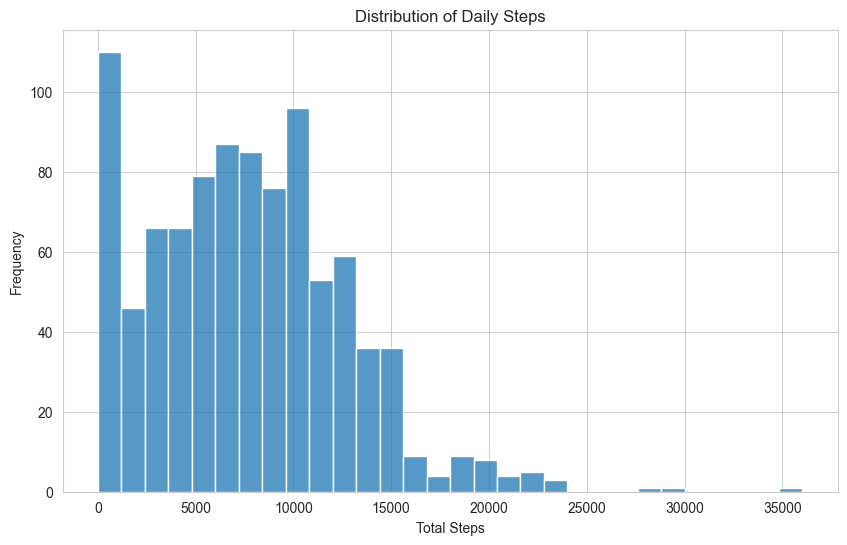

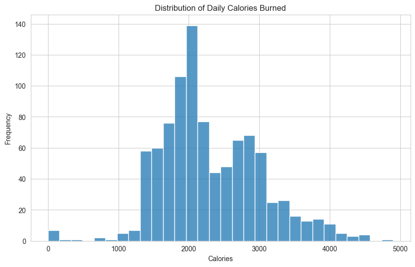

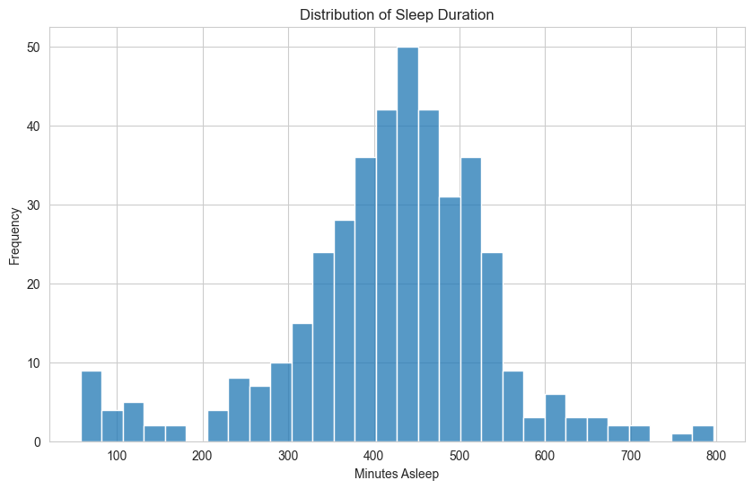

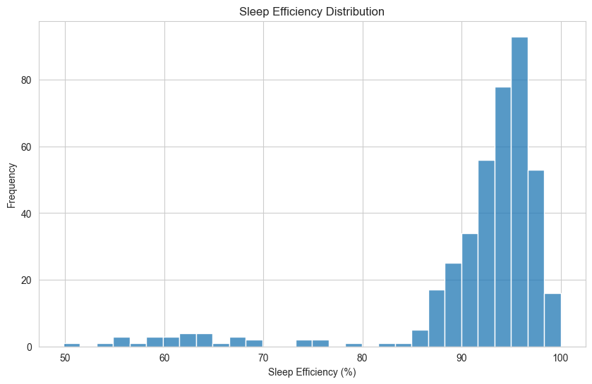

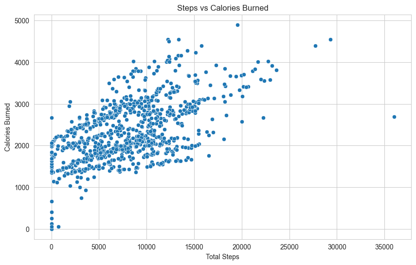

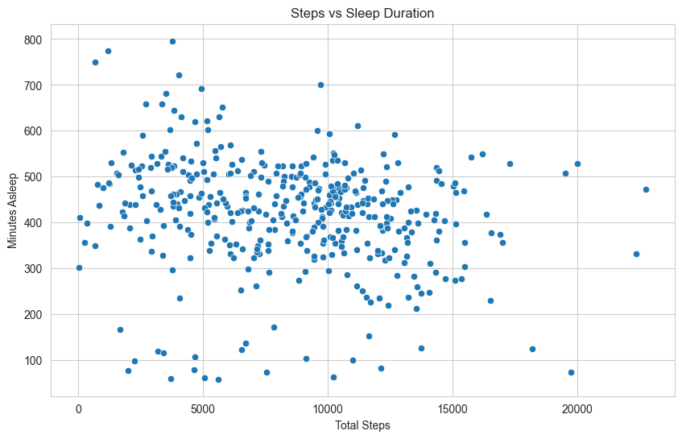

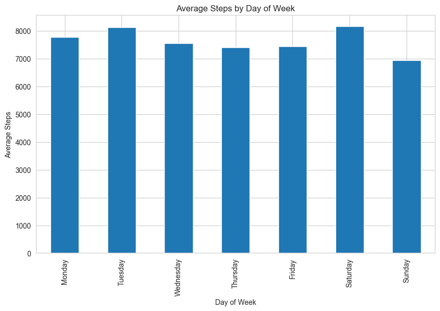

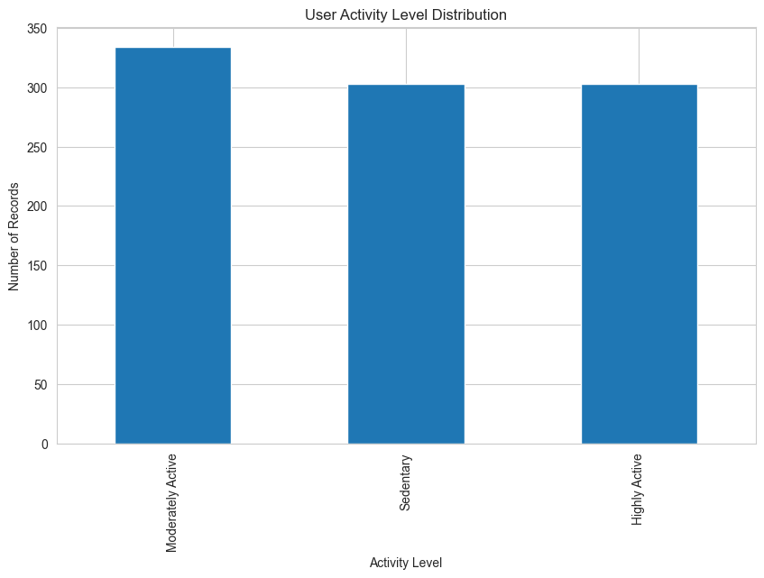

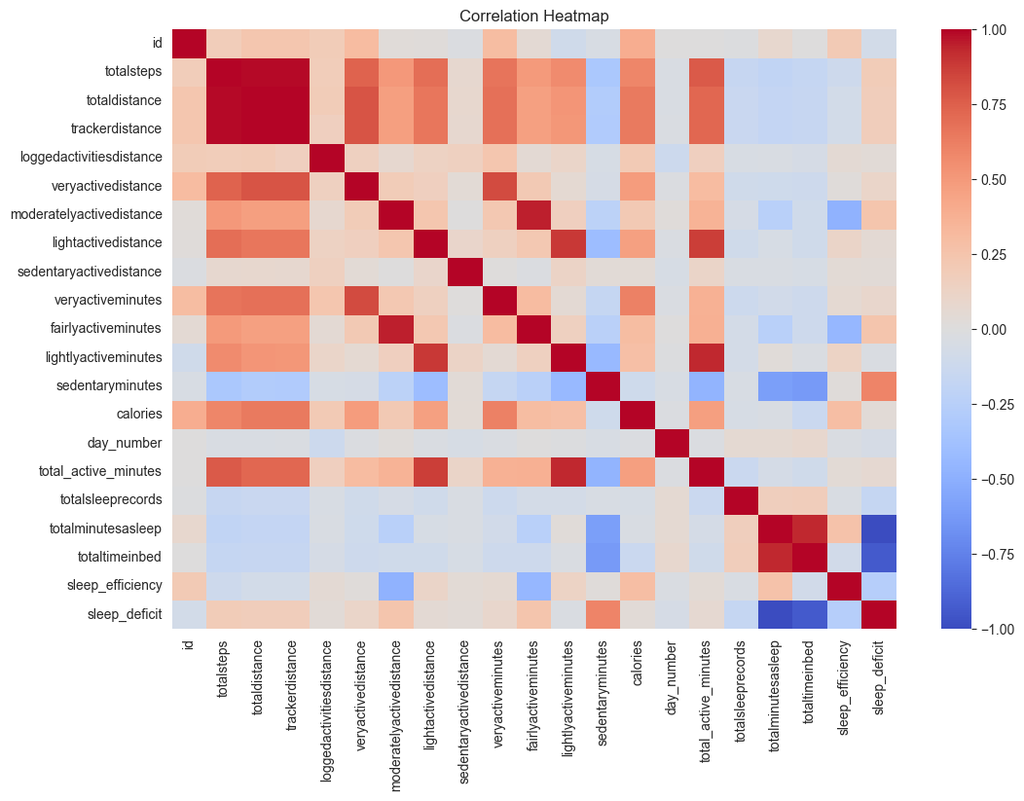

```python
# ===============================================
# STEP 5.3 - ACTIVITY BEHAVIOR PATTERNS
# ===============================================

plt.figure(figsize=(10,6))
sns.histplot(daily_merged['totalsteps'], bins=30)

plt.title("Distribution of Daily Steps")
plt.xlabel("Total Steps")
plt.ylabel("Frequency")

plt.savefig(
    "../outputs/charts/steps_distribution.png",
    dpi=300,
    bbox_inches="tight"
)

plt.show()


plt.figure(figsize=(10,6))
sns.histplot(daily_merged['calories'], bins=30)

plt.title("Distribution of Daily Calories Burned")
plt.xlabel("Calories")
plt.ylabel("Frequency")

plt.savefig(
    "../outputs/charts/calories_distribution.png",
    dpi=300,
    bbox_inches="tight"
)

plt.show()


# ===============================================
# STEP 5.4 - SLEEP BEHAVIOR ANALYSIS
# ===============================================

plt.figure(figsize=(10,6))
sns.histplot(
    daily_merged['totalminutesasleep'].dropna(),
    bins=30
)

plt.title("Distribution of Sleep Duration")
plt.xlabel("Minutes Asleep")
plt.ylabel("Frequency")

plt.savefig(
    "../outputs/charts/sleep_duration_distribution.png",
    dpi=300,
    bbox_inches="tight"
)

plt.show()


# Sleep Efficiency

daily_merged['sleep_efficiency'] = (
    daily_merged['totalminutesasleep']
    / daily_merged['totaltimeinbed']
) * 100

plt.figure(figsize=(10,6))
sns.histplot(
    daily_merged['sleep_efficiency'].dropna(),
    bins=30
)

plt.title("Sleep Efficiency Distribution")
plt.xlabel("Sleep Efficiency (%)")
plt.ylabel("Frequency")

plt.savefig(
    "../outputs/charts/sleep_efficiency_distribution.png",
    dpi=300,
    bbox_inches="tight"
)

plt.show()


# ===============================================
# STEP 5.5 - ACTIVITY VS CALORIES
# ===============================================

plt.figure(figsize=(10,6))

sns.scatterplot(
    data=daily_merged,
    x='totalsteps',
    y='calories'
)

plt.title("Steps vs Calories Burned")
plt.xlabel("Total Steps")
plt.ylabel("Calories Burned")

plt.savefig(
    "../outputs/charts/steps_vs_calories.png",
    dpi=300,
    bbox_inches="tight"
)

plt.show()


# ===============================================
# STEP 5.6 - ACTIVITY VS SLEEP
# ===============================================

plt.figure(figsize=(10,6))

sns.scatterplot(
    data=daily_merged,
    x='totalsteps',
    y='totalminutesasleep'
)

plt.title("Steps vs Sleep Duration")
plt.xlabel("Total Steps")
plt.ylabel("Minutes Asleep")

plt.savefig(
    "../outputs/charts/steps_vs_sleep.png",
    dpi=300,
    bbox_inches="tight"
)

plt.show()


# ===============================================
# STEP 5.7 - WEEKDAY VS WEEKEND ANALYSIS
# ===============================================

weekday_order = [
    "Monday",
    "Tuesday",
    "Wednesday",
    "Thursday",
    "Friday",
    "Saturday",
    "Sunday"
]

weekday_analysis = (
    daily_merged
    .groupby('day_of_week')['totalsteps']
    .mean()
    .reindex(weekday_order)
)

plt.figure(figsize=(10,6))

weekday_analysis.plot(kind='bar')

plt.title("Average Steps by Day of Week")
plt.xlabel("Day of Week")
plt.ylabel("Average Steps")

plt.savefig(
    "../outputs/charts/weekday_activity.png",
    dpi=300,
    bbox_inches="tight"
)

plt.show()


# ===============================================
# STEP 5.8 - ACTIVITY SEGMENT INSIGHT
# ===============================================

activity_levels = (
    daily_merged['activity_level']
    .value_counts()
)

plt.figure(figsize=(10,6))

activity_levels.plot(kind='bar')

plt.title("User Activity Level Distribution")
plt.xlabel("Activity Level")
plt.ylabel("Number of Records")

plt.savefig(
    "../outputs/charts/activity_segments.png",
    dpi=300,
    bbox_inches="tight"
)

plt.show()


# ===============================================
# STEP 5.9 - CORRELATION ANALYSIS
# ===============================================

numeric_cols = daily_merged.select_dtypes(include='number')

plt.figure(figsize=(12,8))

sns.heatmap(
    numeric_cols.corr(),
    annot=False,
    cmap='coolwarm'
)

plt.title("Correlation Heatmap")

plt.savefig(
    "../outputs/charts/correlation_heatmap.png",
    dpi=300,
    bbox_inches="tight"
)

plt.show()
```

# =====================================================

# STEP 6.0 - FINAL INSIGHTS & RECOMMENDATIONS

# =====================================================

## STEP 6.1 - EXECUTIVE SUMMARY

This analysis examined user activity, sleep behavior, calorie expenditure, heart rate observations, and weight records from Fitbit smart device users.

The objective was to identify behavioral patterns that could support data-driven recommendations for Bellabeat's wellness products and marketing strategies.

Following data cleaning, feature engineering, relational integration, and exploratory analysis, several meaningful trends emerged regarding physical activity, sleep habits, and user engagement.

# STEP 6.2 - KEY FINDINGS

## 1. Significant Variation in Physical Activity

Daily step counts varied substantially across users, indicating the presence of distinct activity segments ranging from sedentary to highly active individuals.

## 3. Sleep Patterns Vary Across Users

Sleep duration and sleep efficiency varied considerably among participants, suggesting opportunities for personalized sleep coaching and monitoring.

## 4. Behavioral Differences Across Days of the Week

Activity levels showed noticeable variation across weekdays and weekends, indicating that user routines influence wellness behaviors.

## 5. Majority of Users Are Not Consistently Highly Active

Activity segmentation revealed that many users fall within sedentary or moderately active categories, highlighting potential opportunities for behavior-change interventions.

# STEP 6.3 - BUSINESS RECOMMENDATIONS

## Recommendation 1: Promote Activity-Based Goal Setting

Bellabeat should emphasize personalized step goals and daily movement targets within its mobile application. Users exhibiting lower activity levels may benefit from adaptive coaching and motivational reminders.

## Recommendation 2: Expand Sleep Coaching Features

Given the variability observed in sleep behavior, Bellabeat can strengthen its value proposition through enhanced sleep analytics, bedtime recommendations, and recovery tracking.

## Recommendation 3: Introduce Behavioral Segmentation

Users should be segmented according to activity levels (Sedentary, Moderately Active, Highly Active) to support personalized content, notifications, and wellness recommendations.

## Recommendation 4: Leverage Weekly Behavioral Trends

Marketing campaigns and in-app challenges can be strategically scheduled around periods of lower engagement to encourage consistent wellness habits.

## Recommendation 5: Develop Integrated Wellness Dashboards

Combining activity, sleep, and physiological metrics into a unified wellness score may help users better understand the relationship between daily behaviors and overall health outcomes.

## Step 6.4 - Project Conclusion

The Fitbit dataset provides valuable insight into user wellness behaviors, particularly in relation to physical activity, sleep habits, and calorie expenditure.

The analysis revealed substantial variation in activity levels and sleep patterns, highlighting opportunities for personalized health interventions.

By leveraging these behavioral insights, Bellabeat can enhance user engagement through targeted coaching, personalized wellness recommendations, and data-driven product development strategies.

Future analysis could incorporate additional physiological indicators such as aggregated heart rate metrics and longitudinal weight tracking to further strengthen wellness modeling capabilities.

## STEP 6.5 - LIMITATIONS

1. The dataset represents a limited sample of Fitbit users and may not fully represent the broader wearable device market.
2. The weight log dataset contained limited observations, restricting the depth of weight-related analysis.
3. Heart rate data was available at a much finer temporal granularity and was not fully integrated into the daily analytical layer.
4. The analysis focused primarily on descriptive analytics and does not establish causal relationships between variables.

```python
# ===============================================
# STEP 7.0 - EXPORT PROCESSED DATASETS
# ===============================================

# Verify analytical datasets exist
print("Daily Merged:", type(daily_merged))
print("Hourly Merged:", type(hourly_merged))

# ===============================================
# EXPORT CLEANED DATASETS
# ===============================================

daily_activity.to_csv(
    "../data/processed/daily_activity_clean.csv",
    index=False
)

sleep.to_csv(
    "../data/processed/sleep_clean.csv",
    index=False
)

hourly_steps.to_csv(
    "../data/processed/hourly_steps_clean.csv",
    index=False
)

hourly_calories.to_csv(
    "../data/processed/hourly_calories_clean.csv",
    index=False
)

heart_rate.to_csv(
    "../data/processed/heart_rate_clean.csv",
    index=False
)

weight_log.to_csv(
    "../data/processed/weight_log_clean.csv",
    index=False
)

# ===============================================
# EXPORT ANALYTICAL DATASETS
# ===============================================

daily_merged.to_csv(
    "../data/processed/daily_merged.csv",
    index=False
)

hourly_merged.to_csv(
    "../data/processed/hourly_merged.csv",
    index=False
)

print("=" * 70)
print("PROCESSED DATASETS EXPORTED SUCCESSFULLY")
print("=" * 70)

print("\nFiles Created:")
print("- daily_activity_clean.csv")
print("- sleep_clean.csv")
print("- hourly_steps_clean.csv")
print("- hourly_calories_clean.csv")
print("- heart_rate_clean.csv")
print("- weight_log_clean.csv")
print("- daily_merged.csv")
print("- hourly_merged.csv")
```

```
Daily Merged: <class 'pandas.DataFrame'>
Hourly Merged: <class 'pandas.DataFrame'>
======================================================================
PROCESSED DATASETS EXPORTED SUCCESSFULLY
======================================================================

Files Created:
- daily_activity_clean.csv
- sleep_clean.csv
- hourly_steps_clean.csv
- hourly_calories_clean.csv
- heart_rate_clean.csv
- weight_log_clean.csv
- daily_merged.csv
- hourly_merged.csv
```